# Solutions to homework 4 related to the computer component

```r
rm(list=ls())
```

# General questions

## Question 1

Primarily, training data is

- Answer 1: is a set of observables used to tune the parameters of the ML model. -Correct answer
- Answer 2: is a set of observables used to verify the performance of the ML model

## Question 2

Measure of success (choose that is correct from the choices below)

- Answer 1: is a quantity that indicates how bad the corresponding ML model performs -Correct answer
- Answer 2: can be used for comparisons among different ML models -Correct answer
- Answer 3: is the Risk function among others -Correct answer
- Answer 4: is the Empirical Risk Function among others -Correct answer

## Question 3

In classification problems, all the quantities in the training data set are continuous

- True
- False -Correct answer

## Question 4

Training a Neural network model is in general a convex learning problem.

- True
- False -Correct answer

## Question 5

Convex-Smooth-Bounded Learning Problem with parameters $\beta$, $B$ is is called the learning problem (choose everything that it is correct)

Answer 2: whose the hypothesis class $H$ is a convex set such that $|w|\le B$ for $w\in H$ -Correct answer

Answer 3: the loss function is any convex function

Answer 4: the loss function is any convex function and $\beta$-smooth

Answer 5: the loss function is any convex function , $\beta$-smooth, and non-negative -Correct answer

# Stochastic learning

Consider a predictive rule $h:\mathbb{R}\rightarrow \mathbb{R}$ with

$$h\left(x\right)=w_{0}+w_{1}x$$

and $x\in\mathbb{R}$.

Assume that there is a training data set

$$\mathcal{S}_{n}=\left\{ z_{i}=\left(x_{i},y_{i}\right)\right\} _{i=1}^{n}$$

with $n=100$.

Run the following R script to obtain the training data set $\mathcal{S}_{n}$ as a data frame object with name training.data.1 .

```r
githubURL <-"https://github.com/georgios-stats/Machine_Learning_and_Neural_Networks_III_Epiphany_2023/raw/main/Exercises/misc/Homework_4/training.data.1.Rda"
load(url(githubURL))
```

You will notice that training.data.1 contains two self-explained variables training.data.1$x and training.data.1$y.

Consider a loss function

$$\ell\left(w,z=\left(x,y\right)\right)=\left|y-w_{0}-w_{1}x_{1}\right|$$

and hence Empirical Risk Function

$$\hat{R}_{n}\left(w\right)=\frac{1}{n}\sum_{i=1}^{n}\ell\left(w,z_{i}=\left(x_{i},y_{i}\right)\right)$$

## Question

To learn $w$, code a gradient descent learning algorithm that aims to minimize the Empirical Risk Function under the above loss function and the provided training data set $\mathcal{S}_{n}$.

Your gradient descent algorithm should converge to an optimal value in no more than 50 iterations.

Use any value in the range $(-3,3)\times (-3,3)$ for the seed $w^{(0)}$.

Use a constant learning rate $\eta_{t}$. You have to adjust the value of the learning rate $\eta_{t}$, so that your algorithm can achieve convergence in no more than 50 iterations.

Write down the R code.

```r
loss_fun <- function(w,z) {
  x <- z[1]
  y <- z[2]
  loss_fun <- abs( y -w[1] - w[2]*x )
}
#
empirical_risk_fun <- function(w,z,n) {
  erf <- 0.0
  for (i in 1:n) {
    x <- z[i,1]
    y <- z[i,2]
    erf <- erf + abs( y -w[1] - w[2]*x )
  }
  erf <- erf/n
  return( erf )
}
#
training.data.1
```

| x | y |
| --- | --- |
| 0.48547519 | 1.08335888 |
| -0.76035762 | 0.99495156 |
| 0.92121262 | 2.69233550 |
| 0.63068438 | 2.48726253 |
| 0.43353410 | 1.40274056 |
| 1.10785775 | 1.77704984 |
| 1.79936353 | 2.84467602 |
| 0.77307627 | 2.35502413 |
| 1.73512288 | 2.67083386 |
| 2.05797519 | 2.91284210 |

[output cut: 90 more lines]

```r
z_obs <- as.matrix(training.data.1)
n_obs <- dim(z_obs)[1]
#
#
eta <- 0.5
Tmax <- 50
w_seed <- c(-0,0)
w <- w_seed
w_chain <- c()
Qstop <- 0
t <- 0
while ( Qstop == 0 ) {
  # counter
  t <- t +  1
  cat( t ) ; cat( ' ' ) ## counter added for display reasons
  # step 1: update
  erf_fun <- function(w, z = z_obs, n=n_obs) {
    return( empirical_risk_fun(w, z, n) )
  }
  w <- w - eta * numDeriv::grad( erf_fun, w )
  w_chain <- rbind(w_chain, w)
  # step 2: check for termination terminate
  if ( t>= Tmax ) {
    Qstop <- 1
  }
}
```

```
1 2 3 4 5 6 7 8 9 10 11 12 13 14 15 16 17 18 19 20 21 22 23 24 25 26 27 28 29 30 31 32 33 34 35 36 37 38 39 40 41 42 43 44 45 46 47 48 49 50
```

## Question

Generate the trace plots of $w_{t}$’s, produced by the Gradient Descent algorithm above, against the iteration $t$, and print them in a PDF form.

The trace plots should present a converging chain.

Upload these PDF files.

```r
plot(w_chain[,1], type='l')
dev.copy(pdf,'./misc/Homework_4/gd_w_1.pdf')
```

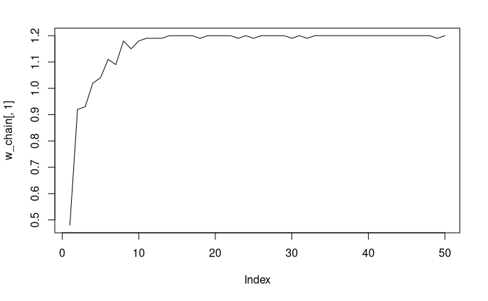

```r
dev.off()
```

```r
#
plot(w_chain[,2], type='l')
dev.copy(pdf,'./misc/Homework_4/gd_w_2.pdf')
```

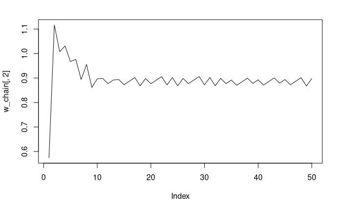

```r
dev.off()
```

## Question

Write down the best value of the $w_{1}$’s discovered by the above gradient descent learning algorithm.

Write down the best value of the $w_{2}$’s discovered by the above gradient descent learning algorithm.

```r
w_opt <- w_chain[1,]
erf_opt <- empirical_risk_fun(w_opt,z_obs,n_obs)
for (i in 2:Tmax) {
  w_now <- w_chain[i,]
  erf_now <- empirical_risk_fun(w_now,z_obs,n_obs)
  if( erf_now < erf_opt) {
    w_opt <- w_now
    erf_opt <- erf_now
  }
}
w_opt
```

```
[1] 1.200000 0.891658
```

```r
colMeans(w_chain[floor(0.75*Tmax):Tmax,])
```

```
[1] 1.1993307 0.8866323
```

## Question

Consider another training data set with size $n=100000$.

Run the following R script to obtain the training data set $\mathcal{S}_{n}$ with size $n=100000$ as a data frame object with name training.data.2

```r
githubURL <-"https://github.com/georgios-stats/Machine_Learning_and_Neural_Networks_III_Epiphany_2023/raw/main/Exercises/misc/Homework_4/training.data.2.Rda"
load(url(githubURL))
```

Assume that your computer cannot process the gradient descent you created above to learn algorithm with the new training data set. In particular, due to your limited computer resources, assume that your computer is able to compute the Empirical Risk Function over $n=10$ (or less) examples (from the training data set).

In a principle manner, modify your gradient descent learning algorithm in order to to address the aforesaid limited resources problem and learn the unknown w’s given the available training data set.

Properly, adjust the parameters of your modified algorithm so that it can converge around the optimal values of w’s in less than 100 iterations.

Use any value in the range $(-3,3)\times (-3,3)$ for the seed $w^{(0)}$.

Copy your modified code below.

Justify why you modified your code that way, and why this is a suitable implementation of the algorithm for the given problem.

```r
# I will implement SGD with batch size m=10 because it stochastically chooses sub-samples smaller than the total sample size, hence the problem of the limited resources is addressed. Because the examples are stochastically chosen after several iterations I could have possibly (and eventually) scan all the availabel training data set.

loss_fun <- function(w,z) {
  x <- z[1]
  y <- z[2]
  loss_fun <- abs( y -w[1] - w[2]*x )
}
#
empirical_risk_fun <- function(w,z,n) {
  erf <- 0.0
  for (i in 1:n) {
    x <- z[i,1]
    y <- z[i,2]
    erf <- erf + abs( y -w[1] - w[2]*x )
  }
  erf <- erf/n
  return( erf )
}
#
training.data.2
```

| x | y |
| --- | --- |
| -0.5145248122 | 1.08335888 |
| -1.7603576202 | 0.99495156 |
| -0.0787873776 | 2.69233550 |
| -0.3693156224 | 2.48726253 |
| -0.5664659005 | 1.40274056 |
| 0.1078577529 | 1.77704984 |
| 0.7993635332 | 2.84467602 |
| -0.2269237269 | 2.35502413 |
| 0.7351228779 | 2.67083386 |
| 1.0579751860 | 2.91284210 |

[output cut: 990 more lines]

```r
z_obs <- as.matrix(training.data.2)
n_obs <- dim(z_obs)[1]
#
#
m <- 10
eta <- 0.8
Tmax <- 100
w_seed <- c(-3,3)
w <- w_seed
w_chain <- c()
Qstop <- 0
t <- 0
while ( Qstop == 0 ) {
  # counter
  t <- t +  1
  cat( t ) ; cat( ' ' ) ## counter added for display reasons
  # step 1: update
  J <- sample.int(n = n_obs, size = m, replace = TRUE)
  if (m==1) {
    zbatch <- matrix(z_obs[J,],1,2)
  }
  else {
    zbatch <- z_obs[J,]
  }
  #eta <- learning_rate( t )
  erf_fun <- function(w, z = zbatch, n=m) {
    return( empirical_risk_fun(w, z, n) )
  }
  w <- w - eta * numDeriv::grad( erf_fun, w )
  w_chain <- rbind(w_chain, w)
  # step 2: check for rtermination terminate
  if ( t>= Tmax ) {
    Qstop <- 1
  }
}
```

```
1 2 3 4 5 6 7 8 9 10 11 12 13 14 15 16 17 18 19 20 21 22 23 24 25 26 27 28 29 30 31 32 33 34 35 36 37 38 39 40 41 42 43 44 45 46 47 48 49 50 51 52 53 54 55 56 57 58 59 60 61 62 63 64 65 66 67 68 69 70 71 72 73 74 75 76 77 78 79 80 81 82 83 84 85 86 87 88 89 90 91 92 93 94 95 96 97 98 99 100
```